# Lecture 16 - Time series

# Time series

依時間先後的變化發生一系列有規則的變化，此得到的變數的觀測值稱為時間序列。也就是同一變數在不同時間點或不同時期的資料，可為日、週、月、季、年資料。e.g. Weather data, Stock prices, Industry forecasts, etc.

Example:

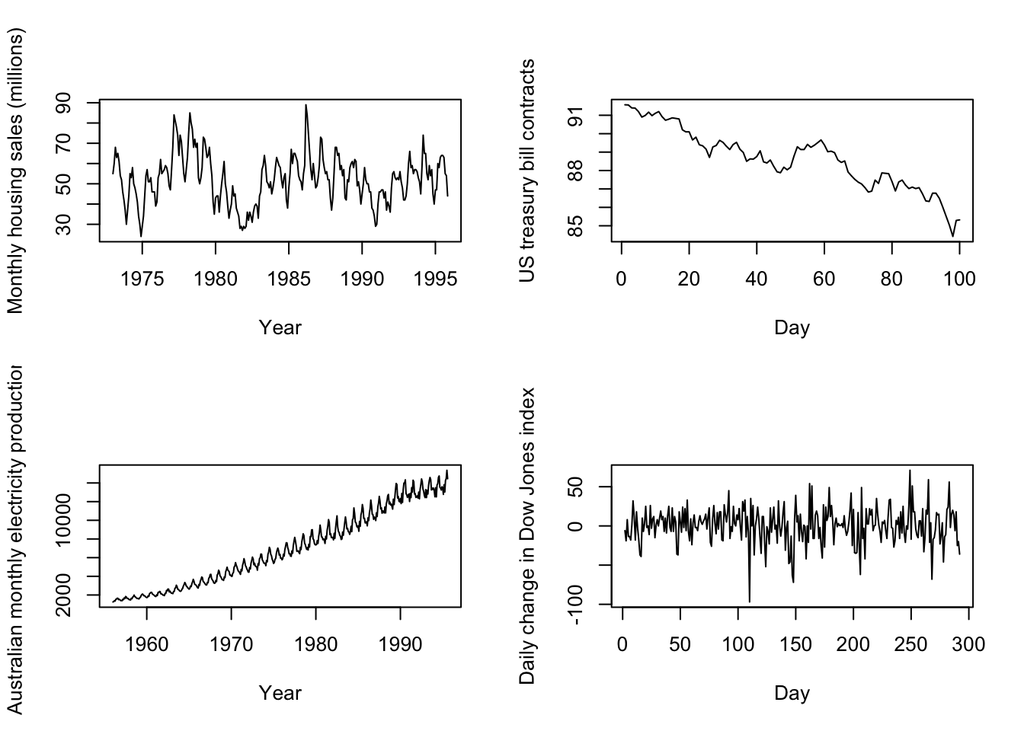

時間序列的分析目的：觀察分析過去資料，以預測未來。

在量化投資中的應用有：

- 對未來的資產價格預測
- 模擬序列
- 探索金融時間序列的趨勢和週期性
- 時間序列與其他變數的內在關係，為策略提供輔助和增強
- 不同時間序列之間的關係，發現新的策略
- 波動率建模，期權相關的策略

時間序列由這些組成:

- T固定趨勢trend：長時間呈現上升或下降的持續變動的現象
- S季節變動seasonal：依週、月或季連續規則性的變動(每年有一樣的變動)(定義在一年之間)
- R不規則變動random variation：隨機的變動(不能被預測的事件:戰爭、抗議)

在剔除趨勢和季節效應後，時間序列在不同時點上是存在相關性的，這種自相關特徵是我們對時間序列建模的基礎。

```
library(forecast)
ts(vector, start=, end=, frequency=)  #convert a numeric vector into an R time series
```

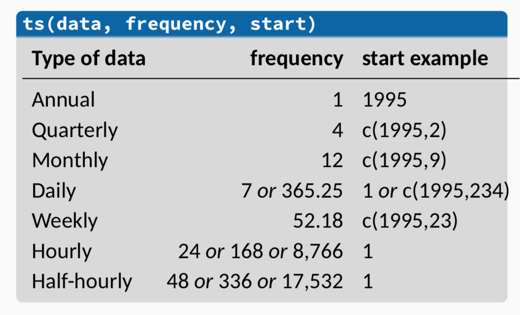

分解數據：

相加模型(Additive) $Y_t=S_t+T_t+R_t$ (每年季節變動差不多用)

相乘模型(Multiplicative) $Y_t=S_t \times T_t \times R_t$ (每年季節變動隨時間增加用)(此模型假設這些因子非獨立)

相加＝log(相乘)

Additive and Multiplicative:

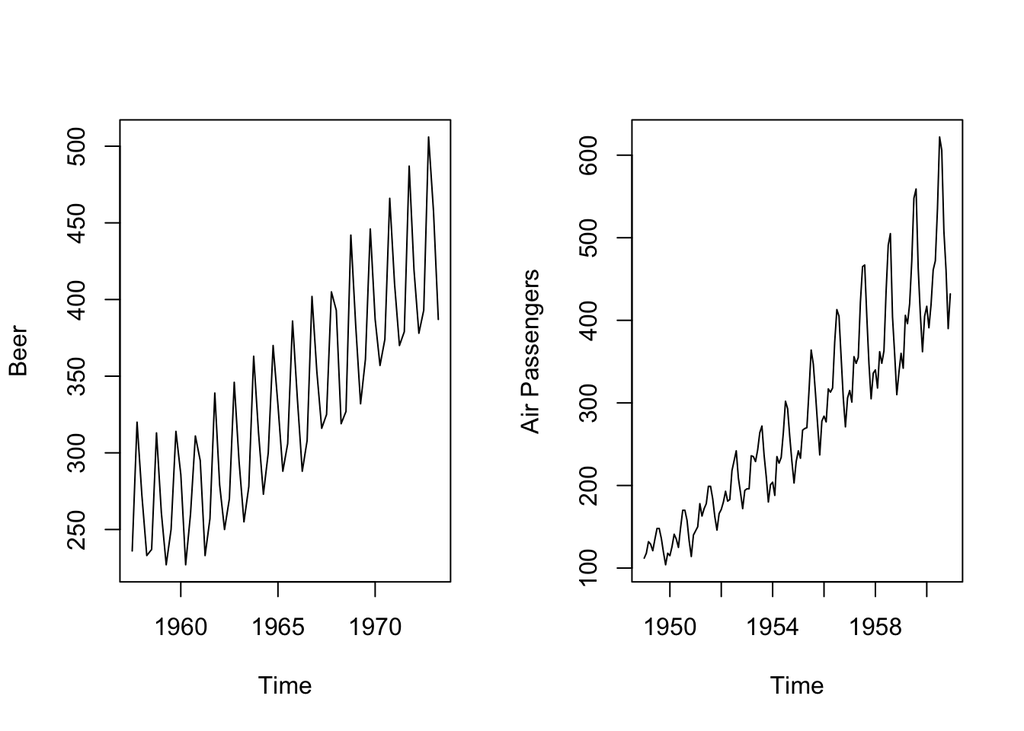

```
decompose(data,type='additive') #splits the time series into seasonality, trend and error components.

stl(data, s.window="periodic")  #By LOESS. splits the time series into seasonality, trend and error components.

seasonal() #extracts the seasonal component
trendcycle() #extracts the trend-cycle component
remainder() #extracts the remainder component.
seasadj() #returns the seasonally adjusted series.
```

我們可以分別將趨勢資料與季節資料用以做預測，以得到更準確的預測結果。`tslm(Y~season+Trend)`

### White noise

白雜訊是由一組mean=0，constant variance，相互獨立的元素構成，因此可對該元素的分佈進行假設（如高斯分佈）。且各元素之間沒有任何關係。$\varepsilon$ 是白雜訊。也就是隨機出現的現象。但如果資料是白雜訊就無法分析。

e.g. 迴歸裡的random error 通常被假設為white noise

### Autocorrelation

時間序列資料具有序列相關 (serial correlation), 也就是本期的 資料與之前或是之後的資料具相關性。

Autocorrelation measures the linear relationship between lagged values of a time series.

Time series that show no autocorrelation are called “white noise”

### Stationary Time Series (平穩過程)

若時間序列的統計性質不會隨時間經過而改變(與t無關)，則稱該時間序列 是穩定的 （mean, variance, autocorrelation, etc. are all constant over time）（平穩過程=經濟學的市場均衡）

- The mean value of time-series is constant over time, which implies, the trend component is nullified.
- The variance does not increase over time.
- Seasonality effect is minimal.
- $cov(Y_t,Y_{t+k})=f(k)$不同時間點的資料相關性只與二者相隔時間長短有關，而不與觀察值之時間點有關

希望歷史數據上的一些性質，在將來保持不變（時間平移不變;不隨時間改變），這樣才能描述未來。

若非平穩，則通過差分去除趨勢，直到通過平穩性檢驗。如何檢測 stationarity?

1. 圖形觀察：原始資料圖、差方資料圖
2. 觀察自相關係數函數圖 (ACF 圖)

```
plot(data)
plot(diff(data))
acf(data)
```

非stationary，需對序列進行差分`diff(data)`，再檢定直到stationary

## Forecasting

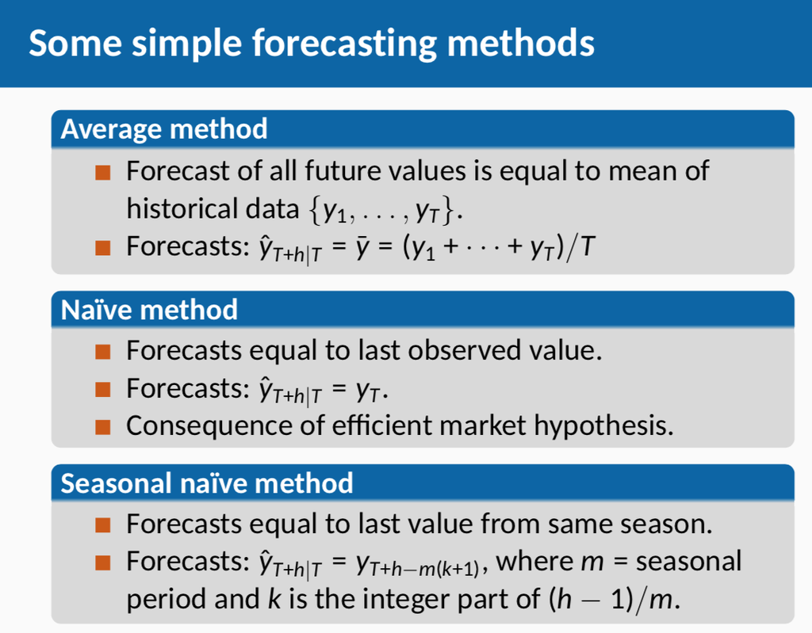

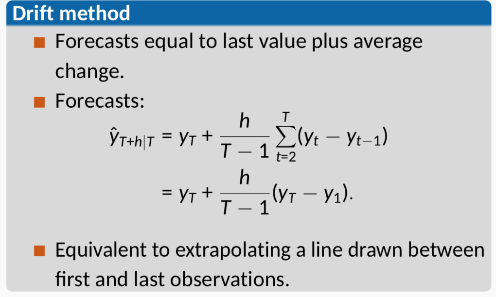

常見三種：

1. 平滑法(smoothing)
   - 移動平均法(moving averages): 將最近的k期資料加以平均
   - 加權移動平均(weighted moving averages): 計算最近k期的平均值，越近的觀察值給予較大權數，越遠的觀察值權數較小，權重和為1。e.g. $(0.3X_{t_1}+0.3X_{t_2}+0.4X_{t_3})/3$
   - 指數平滑法(exponential smoothing)`HoltWinters()`: https://wiki.mbalib.com/zh-tw/%E6%8C%87%E6%95%B0%E5%B9%B3%E6%BB%91%E6%B3%95
2. 趨勢法(trend projection) : $Y=\beta_0+\beta_1 time$
3. 季節修正法(trend projection adjusted for seasonal influence)：$Y_t-S_t=T_t+R_t$

## 自迴歸模型 (AR, Autoregressive Models)

以前面$x_1,\ldots, x_{t-1}$預測這期$x_t$

$X_t=c+\sum_{i=1}^p \phi_iX_{t-i}+\varepsilon_i$,

$\phi$ parameters, $c$ constant, $\varepsilon$ white nouse.

AR(0)：跟前期無關，只跟white noise有關

AR(1)：只跟前一期和white noise有關

AR(2)：跟前兩期和white noise有關

AR模型對偏自相關函數(PACF)截尾,對自相關函數(ACF)拖尾。 所謂截尾指的是從某階開始均為(接近)0的性質,拖尾指的是並不存在某一階突然跳變到0而是逐漸衰減為0。

`ar(data,method)`

## 移動平均模型 (MA, Moving Average Ｍodels)

由同期與過去的隨機項給予不同的權重來解釋。在任何條件下都平穩。 $X_t=\mu+\varepsilon_t+ \theta_1\varepsilon_{t-1}+\ldots+\theta_q\varepsilon_{t-q}$

MA模型對偏自相關函數(PACF)拖尾，對自相關函數(ACF)截尾。在金融模型中，MA常用來刻畫衝擊效應，例如預期之外的事件。

## ARMA模型 (AR, MA 的混合)

$X_t=c+\sum_{i=1}^p \phi_iX_{t-i}+\sum _{j=0}^q \theta_j\varepsilon_{t-j}$,

## ARIMA 模型 (Autoregressive Integrated Moving Average model)

將非平穩的序列進行差分，轉為平穩，後用AR、MA模型

create `acf()`, `pacf()` plots to choose the model.

| Model | ACF | PACF |
| --- | --- | --- |
| ARIMA(p,d,0) | decrease to 0 | p 階後decrease to 0 |
| ARIMA(0,d,q) | q 階後decrease to 0 | decrease to 0 |
| ARIMA(p,d,q) | decrease to 0 | decrease to 0 |

```
arima(data, order=c(0,0,1), method=’ML’,fixed=c(NA,0))
model=arima(data, order=c(0,0,1),method=’ML’) #MA(1). Another method=CSS
str(model) # show the content of model
fitted(model) # values of the fitted model
residuals(model) # residuals for the fitted model

auto.arima(data) # auto select the best model
```

## seasonal ARIMA

請參考：https://otexts.org/fpp2/seasonal-arima.html

## Model diagnostics

### Residual analysis

If the model is correct, the residuals should have nearly the properties of white noise.

```
plot(rstandard(model),ylab="Standardized Residuals",type='o');abline(h=0)
```

Normality of residuals:

```
qqnorm(residuals(model))
qqline(residuals(model))
shapiro.test(residuals(model))
```

Autocorrelation of residuals:

```
acf(residuals(model)) # should within the interval
```

The Ljung-Box Test: The Box-Ljung test (1978) is a diagnostic tool used to test the lack of fit of a time series model.

To study the independence of the residuals, we may takes into account the magnitudes of all residual correlations (r) as a group.

$test= n(n+2)(\frac{r_1^2}{n-1}+\frac{r_2^2}{n-2}+\cdots+\frac{r_k^2}{n-k})$

```
acf(residuals(model))$acf
signif(acf(residuals(model))$acf)
LB.test(model,lag)
Box.tes(model$resid,lag,type="Ljung")
tsdiag(model,gof,omit.initial=F) #gof is the maximum number of lags in the acf function used in the model diagnostics.
```

## Predict

```
forecast <- predict(model, n.ahead = 21)
forecast(model,21)
plot(model, n.ahead = 21, type = 'o')
```

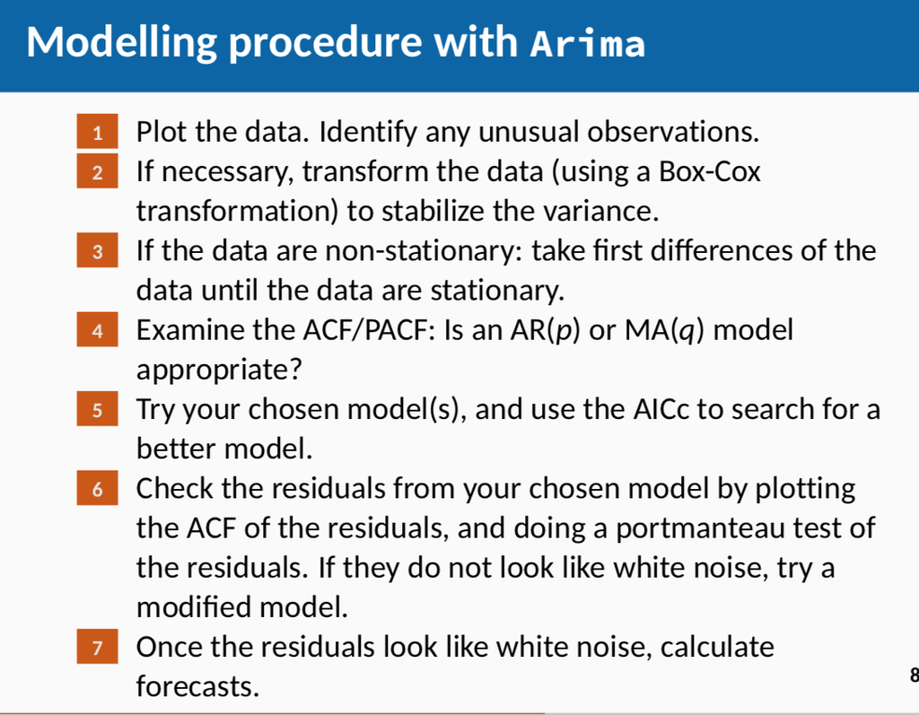

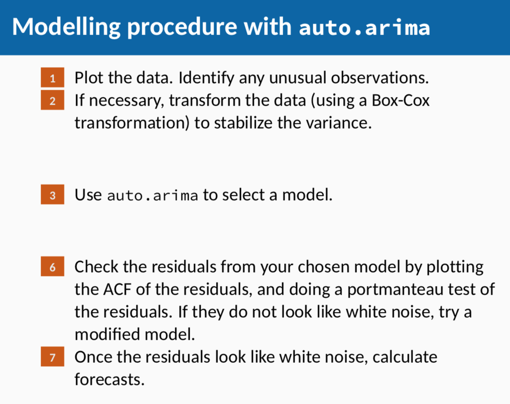

Summary:

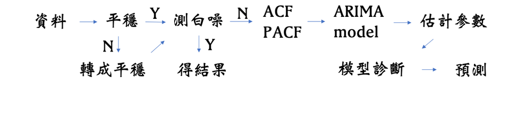

# Exercise

`devtools::install_github("RamiKrispin/TSstudio")`

`library(TSstudio)`

`library(fpp)`

Choose a dataset and have some fun in time series!

dataset: Coffee_Prices, EURO_Brent, Michigan_CS, USgas, USUnRate, USVSales,US_indicators

fpp: https://www.rdocumentation.org/packages/fpp/versions/0.5

## Reference:

https://robjhyndman.com/teaching/

http://staff.ustc.edu.cn/~jbs/Rts.pdf

https://media.readthedocs.org/pdf/a-little-book-of-r-for-time-series/latest/a-little-book-of-r-for-time-series.pdf

https://otexts.com/fpp2/